# RDA project

JBNU statistics

2021 12 14

## 목적 : 단동 비닐하우스 환기율 및 온습도에 대한 예측모형 구축 및 평가

## 사용모형 : Multiple Linear Regression Model v.s Artificial Neural Network Model (ANN)

## 1. Loading data (내부상대습도 반응변수)

- 작물있음 데이터에서 외부CO2의 값이 결측치인 경우는 제외하였음.

```r
plantyes <- read.csv("C:/Users/HSY/Desktop/작물있음.csv",sep=",",header=T)
plantyes <- plantyes[is.na(plantyes$외부CO2)==FALSE,]
head(plantyes,10)
```

```
##    외부기온 내부기온 내외부기온차 외부상대습도 내부상대습도 내외부상대습도차
## 1      22.9     31.1          8.3         78.7         55.0             23.7
## 2      22.8     29.7          6.9         77.1         58.7             18.4
## 3      23.3     29.7          6.4         75.5         58.4             17.1
## 4      23.6     29.8          6.2         72.9         57.8             15.1
## 5      24.0     30.0          6.0         71.2         56.4             14.8
## 6      25.1     33.3          8.1         66.6         49.6             17.0
## 7      25.9     35.6          9.7         66.0         43.6             22.4
## 8      25.0     34.0          8.9         68.0         44.9             23.1
## 9      25.9     33.7          7.8         65.6         46.4             19.2
## 10     26.8     35.9          9.1         61.8         44.1             17.7
##    외부CO2 내부CO2 내외부CO2차 외부풍속 외부일사량 환기율 환기창면적 작물유무
## 1    469.5   462.0         7.5    1.398      372.7    5.4       0.15      yes
## 2    464.5   459.7         4.8    1.326      309.9    5.0       0.15      yes
## 3    457.5   451.3         6.2    0.835      291.9    4.0       0.15      yes
```

[output cut: 18 more lines]

```r
plantyes$작물유무 <- as.factor(plantyes$작물유무)
plantno <- read.csv("C:/Users/HSY/Desktop/작물없음.csv",sep=",",header=T)
head(plantno,10)
```

```
##    외부기온 내부기온 내외부기온차 외부상대습도 내부상대습도 내외부상대습도차
## 1      16.8     27.1         10.3         45.1         39.6              5.5
## 2      17.2     28.3         11.1         42.5         37.6              4.9
## 3      17.6     29.1         11.5         42.9         33.2              9.7
## 4      18.0     30.3         12.4         41.2         32.4              8.8
## 5      17.9     30.6         12.7         37.2         28.8              8.4
## 6      18.0     31.3         13.3         37.4         27.1             10.3
## 7      18.0     31.7         13.7         35.8         25.3             10.5
## 8      18.0     32.0         14.0         38.6         24.4             14.2
## 9      18.3     32.7         14.5         37.0         23.5             13.5
## 10     18.3     32.6         14.3         36.1         22.6             13.5
##    외부CO2 내부CO2 내외부CO2차 외부풍속 외부일사량 환기율 환기창면적 작물유무
## 1    543.5   608.0        64.5    1.576      409.4  0.704       0.04       no
## 2    543.0   580.0        37.0    1.707      442.7  0.756       0.04       no
## 3    522.5   585.5        63.0    1.342      476.5  0.634       0.04       no
```

[output cut: 18 more lines]

```r
plantno$작물유무 <- as.factor(plantno$작물유무)
plant <- rbind(plantno,plantyes)
```

## Multiple Linear Regression Model

## 2. 작물유무에 따라 데이터를 나누어서 분석 실시

### 2.1 작물이 없을 때

#### Multiple Linear Regression Model

- 먼저 변수들 간의 상관관계를 파악하기 위해 상관분석을 실시한다.

```r
ex1 <- plantno[,c(5,12,1,4,10,11,13,14,15)]
head(ex1)
```

```
##   내부상대습도 환기율 외부기온 외부상대습도 외부풍속 외부일사량 환기창면적
## 1         39.6  0.704     16.8         45.1    1.576      409.4       0.04
## 2         37.6  0.756     17.2         42.5    1.707      442.7       0.04
## 3         33.2  0.634     17.6         42.9    1.342      476.5       0.04
## 4         32.4  0.798     18.0         41.2    1.802      505.7       0.04
## 5         28.8  1.084     17.9         37.2    2.583      536.0       0.04
## 6         27.1  1.493     18.0         37.4    3.660      564.9       0.04
##   작물유무 작물유무수치
## 1       no            0
## 2       no            0
## 3       no            0
## 4       no            0
## 5       no            0
## 6       no            0
```

```r
ex2 <- ex1[,1:7]
```

```r
cor(ex2)
```

```
##              내부상대습도      환기율      외부기온  외부상대습도      외부풍속
## 내부상대습도   1.00000000  0.03830334 -6.449731e-01  9.005712e-01 -3.074174e-01
## 환기율         0.03830334  1.00000000  1.668245e-01 -1.981440e-01  5.063954e-01
## 외부기온      -0.64497307  0.16682446  1.000000e+00 -5.264263e-01  3.063871e-01
## 외부상대습도   0.90057115 -0.19814405 -5.264263e-01  1.000000e+00 -3.759817e-01
## 외부풍속      -0.30741742  0.50639545  3.063871e-01 -3.759817e-01  1.000000e+00
## 외부일사량    -0.44775399  0.06080400  3.274643e-01 -2.797394e-01  4.772916e-02
## 환기창면적     0.23499337  0.83095301 -9.044468e-20 -3.217364e-20  3.715441e-20
##                 외부일사량    환기창면적
## 내부상대습도 -4.477540e-01  2.349934e-01
## 환기율        6.080400e-02  8.309530e-01
## 외부기온      3.274643e-01 -9.044468e-20
## 외부상대습도 -2.797394e-01 -3.217364e-20
## 외부풍속      4.772916e-02  3.715441e-20
## 외부일사량    1.000000e+00 -5.089237e-20
## 환기창면적   -5.089237e-20  1.000000e+00
```

- 산점도행렬과 상관계수그림을 그리면 다음과 같다.

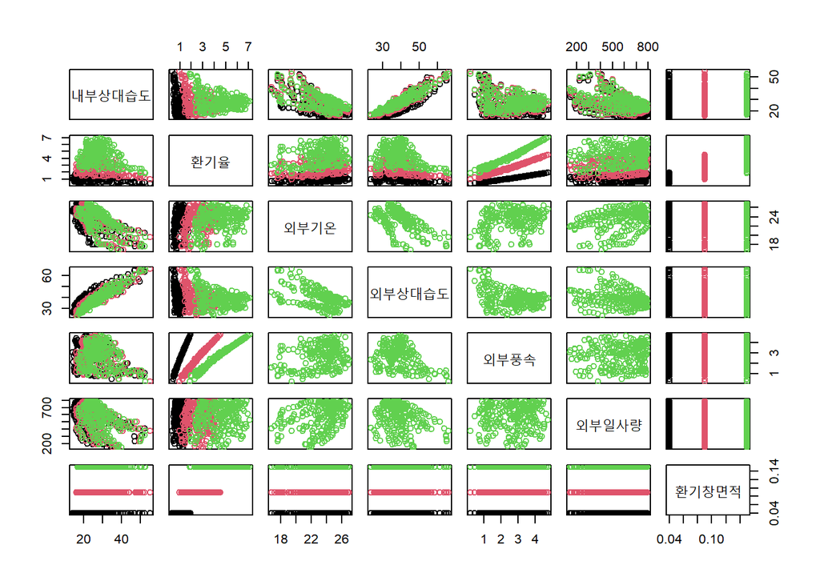

```r
pairs(ex2[1:nrow(plantno),],col=factor(ex2$환기창면적))
```

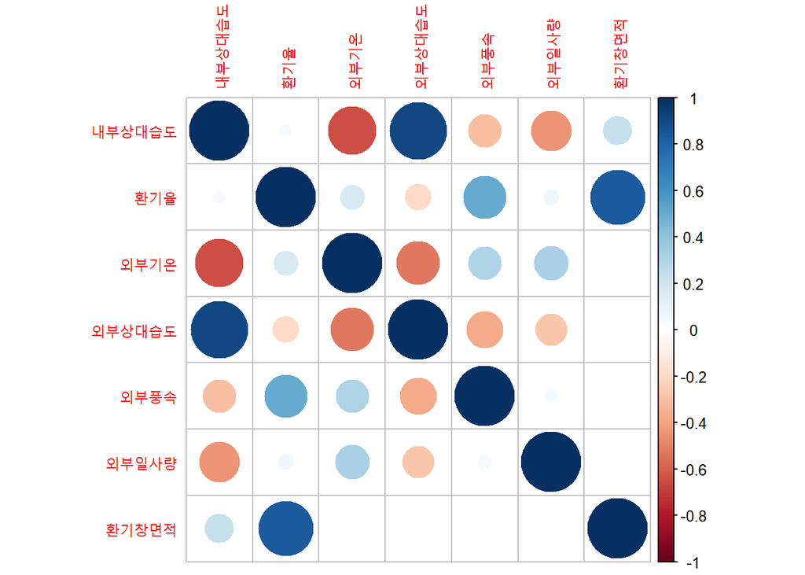

```r
library(corrplot)
corrplot(cor(ex2))
```

- 그리고 각 변수에 대한 기초통계량은 다음과 같이 계산된다.

```r
library(psych)
describe(ex1[,c(-8,-9)])
```

```
##              vars   n   mean     sd median trimmed    mad    min    max  range
## 내부상대습도    1 735  26.26   7.79  24.70   25.32   6.52  14.00  55.10  41.10
## 환기율          2 735   2.81   1.64   2.64    2.68   1.86   0.32   7.09   6.78
## 외부기온        3 735  23.39   2.30  24.00   23.66   1.93  16.80  27.00  10.20
## 외부상대습도    4 735  39.39   7.86  38.70   38.68   6.08  23.60  65.90  42.30
## 외부풍속        5 735   2.71   1.08   2.87    2.73   1.29   0.21   4.74   4.54
## 외부일사량      6 735 568.60 171.31 601.10  584.32 191.40 143.00 795.20 652.20
## 환기창면적      7 735   0.09   0.04   0.09    0.09   0.07   0.04   0.15   0.11
##               skew kurtosis   se
## 내부상대습도  1.18     1.39 0.29
## 환기율        0.55    -0.67 0.06
## 외부기온     -0.98     0.30 0.08
## 외부상대습도  1.00     1.43 0.29
## 외부풍속     -0.26    -0.99 0.04
## 외부일사량   -0.63    -0.61 6.32
## 환기창면적    0.11    -1.50 0.00
```

- 내부상대습도를 반응변수로 하여 각 변수의 주효과와 환기창면적과의 교호작용을 고려한 다중선형회귀모형을 적합하면 다음과 같다.

```r
m_no <- lm(내부상대습도~환기율+외부기온+외부상대습도+외부풍속+외부일사량+환기창면적+환기창면적*환기율+환기창면적*외부기온+환기창면적*외부상대습도+환기창면적*외부풍속+환기창면적*외부일사량,data=plantno)
summary(m_no)
```

```
##
## Call:
## lm(formula = 내부상대습도 ~ 환기율 + 외부기온 + 외부상대습도 +
##     외부풍속 + 외부일사량 + 환기창면적 + 환기창면적 * 환기율 +
##     환기창면적 * 외부기온 + 환기창면적 * 외부상대습도 + 환기창면적 *
##     외부풍속 + 환기창면적 * 외부일사량, data = plantno)
##
## Residuals:
##     Min      1Q  Median      3Q     Max
## -5.3212 -0.9290 -0.0699  0.8435  8.6254
##
## Coefficients:
##                           Estimate Std. Error t value Pr(>|t|)
## (Intercept)              2.516e+01  2.369e+00  10.622  < 2e-16 ***
## 환기율                  -4.266e+00  6.681e-01  -6.385 3.06e-10 ***
## 외부기온                -1.087e+00  7.714e-02 -14.087  < 2e-16 ***
## 외부상대습도             7.083e-01  2.278e-02  31.086  < 2e-16 ***
## 외부풍속                -1.085e+00  1.691e-01  -6.416 2.53e-10 ***
## 외부일사량              -1.171e-02  9.122e-04 -12.841  < 2e-16 ***
## 환기창면적              -6.590e+01  2.367e+01  -2.784   0.0055 **
## 환기율:환기창면적       -2.053e+01  1.751e+00 -11.727  < 2e-16 ***
## 외부기온:환기창면적      4.359e+00  7.444e-01   5.856 7.20e-09 ***
## 외부상대습도:환기창면적  5.999e-01  2.202e-01   2.724   0.0066 **
## 외부풍속:환기창면적      6.981e+01  6.640e+00  10.513  < 2e-16 ***
## 외부일사량:환기창면적    6.822e-02  9.592e-03   7.112 2.75e-12 ***
## ---
## Signif. codes:  0 '***' 0.001 '**' 0.01 '*' 0.05 '.' 0.1 ' ' 1
##
## Residual standard error: 1.704 on 723 degrees of freedom
## Multiple R-squared:  0.9529, Adjusted R-squared:  0.9522
## F-statistic:  1331 on 11 and 723 DF,  p-value: < 2.2e-16
```

- 모형적합 결과 모든 주효과와 교호작용이 유의수준 0.05에서 유의미하다.
- 그리고 교호작용들 중 환기율과 환기창면적, 그리고 외부풍속과 환기창면적 사이의 교호작용에 대한 t 통계량의 절대값이 첫번째와 두번째 순으로 가장 크므로 이를 가장 중요한 2가지 교호작용으로 결정한다.
- 조정된 결정계수의 값이 $R^2_{adj}=0.9522$이다.

#### Best subset selection

- 여러 측도들을 이용하여 모형에 포함될 변수를 적절히 선택해 보도록 하겠다.
- 분석 의뢰기관의 요청에 따라 환기율은 설명변수에서 제외하도록 한다.

```r
library(leaps)
ms0 <- regsubsets(내부상대습도~외부기온+외부상대습도+외부풍속+외부일사량+환기창면적+환기창면적*외부기온+환기창면적*외부상대습도+환기창면적*외부풍속+환기창면적*외부일사량,data=plantno,nvmax=9)
ms0.summary <- summary(ms0)
ms0.summary
```

```
## Subset selection object
## Call: regsubsets.formula(내부상대습도 ~ 외부기온 + 외부상대습도 + 외부풍속 +
##     외부일사량 + 환기창면적 + 환기창면적 * 외부기온 + 환기창면적 *
##     외부상대습도 + 환기창면적 * 외부풍속 + 환기창면적 * 외부일사량,
##     data = plantno, nvmax = 9)
## 9 Variables  (and intercept)
##                         Forced in Forced out
## 외부기온                    FALSE      FALSE
## 외부상대습도                FALSE      FALSE
## 외부풍속                    FALSE      FALSE
## 외부일사량                  FALSE      FALSE
## 환기창면적                  FALSE      FALSE
## 외부기온:환기창면적         FALSE      FALSE
## 외부상대습도:환기창면적     FALSE      FALSE
## 외부풍속:환기창면적         FALSE      FALSE
## 외부일사량:환기창면적       FALSE      FALSE
## 1 subsets of each size up to 9
## Selection Algorithm: exhaustive
##          외부기온 외부상대습도 외부풍속 외부일사량 환기창면적
## 1  ( 1 ) " "      "*"          " "      " "        " "
## 2  ( 1 ) " "      "*"          " "      " "        "*"
## 3  ( 1 ) " "      "*"          " "      "*"        " "
## 4  ( 1 ) "*"      "*"          " "      "*"        " "
## 5  ( 1 ) "*"      "*"          " "      "*"        " "
## 6  ( 1 ) "*"      "*"          " "      "*"        "*"
## 7  ( 1 ) "*"      "*"          " "      "*"        "*"
## 8  ( 1 ) "*"      "*"          "*"      "*"        "*"
## 9  ( 1 ) "*"      "*"          "*"      "*"        "*"
##          외부기온:환기창면적 외부상대습도:환기창면적 외부풍속:환기창면적
## 1  ( 1 ) " "                 " "                     " "
## 2  ( 1 ) " "                 " "                     " "
## 3  ( 1 ) " "                 " "                     " "
## 4  ( 1 ) "*"                 " "                     " "
## 5  ( 1 ) " "                 " "                     "*"
## 6  ( 1 ) "*"                 " "                     "*"
## 7  ( 1 ) "*"                 " "                     "*"
## 8  ( 1 ) "*"                 " "                     "*"
## 9  ( 1 ) "*"                 "*"                     "*"
##          외부일사량:환기창면적
## 1  ( 1 ) " "
## 2  ( 1 ) " "
## 3  ( 1 ) "*"
## 4  ( 1 ) " "
## 5  ( 1 ) "*"
## 6  ( 1 ) " "
## 7  ( 1 ) "*"
## 8  ( 1 ) "*"
## 9  ( 1 ) "*"
```

```r
par(mfrow=c(2,2))
# RSS=SSE
plot(ms0.summary$rss,xlab="Number of Variables",ylab="RSS",type="l")
# Adj R^2
plot(ms0.summary$adjr2,xlab="Number of Variables",ylab="Adjusted RSq",type="l")
which.max(ms0.summary$adjr2)
```

```
## [1] 9
```

```r
points(which.max(ms0.summary$adjr2)
,ms0.summary$adjr2[which.max(ms0.summary$adjr2)
], col="red",cex=2,pch=20)
# Cp
plot(ms0.summary$cp,xlab="Number of Variables",ylab="Cp",type='l')
which.min(ms0.summary$cp)
```

```
## [1] 9
```

```r
points(which.min(ms0.summary$cp)
,ms0.summary$cp[which.min(ms0.summary$cp)
],col="red",cex=2,pch=20)
# BIC
plot(ms0.summary$bic,xlab="Number of Variables",ylab="BIC",type='l')
which.min(ms0.summary$bic)
```

```
## [1] 7
```

```r
points(which.min(ms0.summary$bic)
,ms0.summary$bic[which.min(ms0.summary$bic)
],col="red",cex=2,pch=20)
```

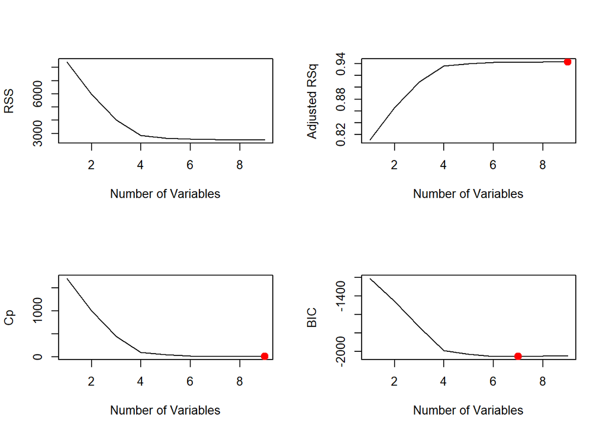

```r
par(mfrow=c(1,1))
```

- 외부풍속을 제외하는 것이 좋다는 결과이다.
- 외부풍속을 제외한 모형에 대해서 다시한번 선택해 보자.

```r
library(leaps)
ms0 <- regsubsets(내부상대습도~외부기온+외부상대습도+외부일사량+환기창면적+환기창면적*외부기온+환기창면적*외부상대습도+환기창면적*외부일사량,data=plantno,nvmax=7)
ms0.summary <- summary(ms0)
ms0.summary
```

```
## Subset selection object
## Call: regsubsets.formula(내부상대습도 ~ 외부기온 + 외부상대습도 + 외부일사량 +
##     환기창면적 + 환기창면적 * 외부기온 + 환기창면적 * 외부상대습도 +
##     환기창면적 * 외부일사량, data = plantno, nvmax = 7)
## 7 Variables  (and intercept)
##                         Forced in Forced out
## 외부기온                    FALSE      FALSE
## 외부상대습도                FALSE      FALSE
## 외부일사량                  FALSE      FALSE
## 환기창면적                  FALSE      FALSE
## 외부기온:환기창면적         FALSE      FALSE
## 외부상대습도:환기창면적     FALSE      FALSE
## 외부일사량:환기창면적       FALSE      FALSE
## 1 subsets of each size up to 7
## Selection Algorithm: exhaustive
##          외부기온 외부상대습도 외부일사량 환기창면적 외부기온:환기창면적
## 1  ( 1 ) " "      "*"          " "        " "        " "
## 2  ( 1 ) " "      "*"          " "        "*"        " "
## 3  ( 1 ) " "      "*"          "*"        " "        " "
## 4  ( 1 ) "*"      "*"          "*"        " "        "*"
## 5  ( 1 ) "*"      "*"          "*"        "*"        "*"
## 6  ( 1 ) "*"      "*"          "*"        "*"        "*"
## 7  ( 1 ) "*"      "*"          "*"        "*"        "*"
##          외부상대습도:환기창면적 외부일사량:환기창면적
## 1  ( 1 ) " "                     " "
## 2  ( 1 ) " "                     " "
## 3  ( 1 ) " "                     "*"
## 4  ( 1 ) " "                     " "
## 5  ( 1 ) " "                     " "
## 6  ( 1 ) " "                     "*"
## 7  ( 1 ) "*"                     "*"
```

```r
par(mfrow=c(2,2))
# RSS=SSE
plot(ms0.summary$rss,xlab="Number of Variables",ylab="RSS",type="l")
# Adj R^2
plot(ms0.summary$adjr2,xlab="Number of Variables",ylab="Adjusted RSq",type="l")
which.max(ms0.summary$adjr2)
```

```
## [1] 6
```

```r
points(which.max(ms0.summary$adjr2)
,ms0.summary$adjr2[which.max(ms0.summary$adjr2)
], col="red",cex=2,pch=20)
# Cp
plot(ms0.summary$cp,xlab="Number of Variables",ylab="Cp",type='l')
which.min(ms0.summary$cp)
```

```
## [1] 6
```

```r
points(which.min(ms0.summary$cp)
,ms0.summary$cp[which.min(ms0.summary$cp)
],col="red",cex=2,pch=20)
# BIC
plot(ms0.summary$bic,xlab="Number of Variables",ylab="BIC",type='l')
which.min(ms0.summary$bic)
```

```
## [1] 6
```

```r
points(which.min(ms0.summary$bic)
,ms0.summary$bic[which.min(ms0.summary$bic)
],col="red",cex=2,pch=20)
```

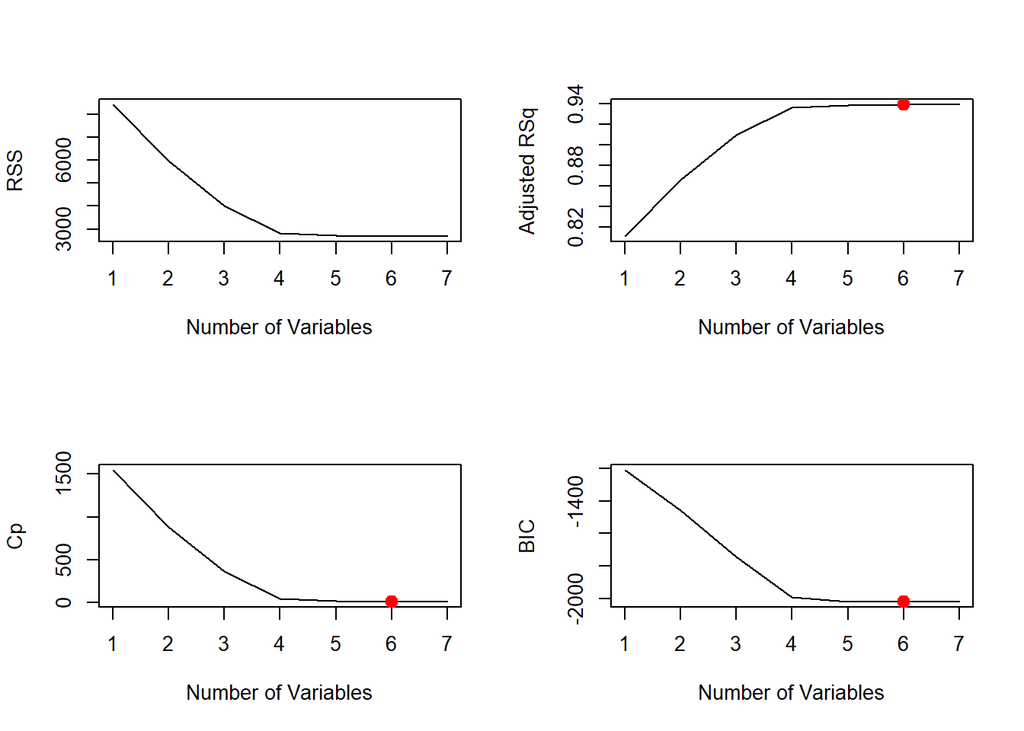

```r
par(mfrow=c(1,1))
```

- 분석결과 6개의 변수를 가지는 모형이 가장 바람직하다고 판단된다.

#### 교차타당검증에 의한 모형 비교

```r
set.seed(5790)
train.index <- sample(1:nrow(plantno), round(nrow(plantno)*7/10), replace=F)
ex1_train <- plantno[train.index,]
ex1_test <- plantno[-train.index,]
```

```r
# 모든 주효과, 그리고 환기창면적과 다른 변수들 사이의 교호작용을 포함한 모형
m0 <- lm(내부상대습도~환기율+외부기온+외부상대습도+외부풍속+외부일사량+환기창면적+환기창면적*환기율+환기창면적*외부기온+환기창면적*외부상대습도+환기창면적*외부풍속+환기창면적*외부일사량,data=ex1_train)
y_hat0 <- predict(m0,ex1_test)
RMSE0 <- mean(sum((ex1_test$내부상대습도-y_hat0)^2))
RMSE0
```

```
## [1] 591.9279
```

```r
# Adj R^2, Cp, BIC 등의 기준을 바탕으로 선택된 모형 (교호작용이 있는 경우는 주효과 포함)
m0 <- lm(내부상대습도~외부기온+외부상대습도+외부일사량+환기창면적+환기창면적*외부기온+환기창면적*외부일사량,data=ex1_train)
y_hat0 <- predict(m0,ex1_test)
RMSE1 <- mean(sum((ex1_test$내부상대습도-y_hat0)^2))
RMSE1
```

```
## [1] 714.9542
```

```r
# 모든 주효과와 가장 중요한 교호작용 1가지를 포함한 모형 (분석 의뢰기관의 요청에 따라 환기율은 제외)
m0 <- lm(내부상대습도~외부기온+외부상대습도+외부풍속+외부일사량+환기창면적+환기창면적*외부풍속,data=ex1_train)
y_hat0 <- predict(m0,ex1_test)
RMSE2 <- mean(sum((ex1_test$내부상대습도-y_hat0)^2))
RMSE2
```

```
## [1] 763.568
```

- 결과적으로 3가지 모형들 중 모든 주효과, 그리고 환기창면적과 다른 변수들 사이의 교호작용을 포함한 모형이 가장 우수하였다.

```r
summary(lm(내부상대습도~환기율+외부기온+외부상대습도+외부풍속+외부일사량+환기창면적+환기창면적*환기율+환기창면적*외부기온+환기창면적*외부상대습도+환기창면적*외부풍속+환기창면적*외부일사량,data=ex1_train))
```

```
##
## Call:
## lm(formula = 내부상대습도 ~ 환기율 + 외부기온 + 외부상대습도 +
##     외부풍속 + 외부일사량 + 환기창면적 + 환기창면적 * 환기율 +
##     환기창면적 * 외부기온 + 환기창면적 * 외부상대습도 + 환기창면적 *
##     외부풍속 + 환기창면적 * 외부일사량, data = ex1_train)
##
## Residuals:
##     Min      1Q  Median      3Q     Max
## -5.4981 -0.9107 -0.0923  0.8335  7.8750
##
## Coefficients:
##                           Estimate Std. Error t value Pr(>|t|)
## (Intercept)              22.698959   2.982275   7.611 1.35e-13 ***
## 환기율                   -4.946523   0.821530  -6.021 3.35e-09 ***
## 외부기온                 -1.045449   0.097404 -10.733  < 2e-16 ***
## 외부상대습도              0.756922   0.028580  26.484  < 2e-16 ***
## 외부풍속                 -1.239504   0.207436  -5.975 4.36e-09 ***
## 외부일사량               -0.011461   0.001185  -9.669  < 2e-16 ***
## 환기창면적              -35.379734  30.419963  -1.163    0.245
## 환기율:환기창면적       -20.439587   2.158192  -9.471  < 2e-16 ***
## 외부기온:환기창면적       3.816057   0.952212   4.008 7.06e-05 ***
## 외부상대습도:환기창면적   0.144853   0.281408   0.515    0.607
## 외부풍속:환기창면적      76.919758   8.279045   9.291  < 2e-16 ***
## 외부일사량:환기창면적     0.067598   0.012346   5.475 6.91e-08 ***
## ---
## Signif. codes:  0 '***' 0.001 '**' 0.01 '*' 0.05 '.' 0.1 ' ' 1
##
## Residual standard error: 1.755 on 502 degrees of freedom
## Multiple R-squared:  0.9523, Adjusted R-squared:  0.9512
## F-statistic: 910.9 on 11 and 502 DF,  p-value: < 2.2e-16
```

### 2.2 작물이 있을 때

#### Multiple Linear Regression Model

- 먼저 변수들 간의 상관관계를 파악하기 위해 상관분석을 실시한다.

```r
ex1 <- plantyes[,c(5,12,1,4,10,11,13,14,15)]
head(ex1)
```

```
##   내부상대습도 환기율 외부기온 외부상대습도 외부풍속 외부일사량 환기창면적
## 1         55.0    5.4     22.9         78.7    1.398      372.7       0.15
## 2         58.7    5.0     22.8         77.1    1.326      309.9       0.15
## 3         58.4    4.0     23.3         75.5    0.835      291.9       0.15
## 4         57.8    4.2     23.6         72.9    0.943      297.5       0.15
## 5         56.4    5.2     24.0         71.2    1.481      335.4       0.15
## 6         49.6    4.9     25.1         66.6    1.132      549.7       0.15
##   작물유무 작물유무수치
## 1      yes            1
## 2      yes            1
## 3      yes            1
## 4      yes            1
## 5      yes            1
## 6      yes            1
```

```r
ex2 <- ex1[,1:7]
```

```r
cor(ex2)
```

```
##              내부상대습도      환기율    외부기온 외부상대습도    외부풍속
## 내부상대습도   1.00000000  0.06820666 -0.70098678   0.91186111  0.03166079
## 환기율         0.06820666  1.00000000  0.04996941  -0.01212264  0.76546935
## 외부기온      -0.70098678  0.04996941  1.00000000  -0.75407969  0.12445561
## 외부상대습도   0.91186111 -0.01212264 -0.75407969   1.00000000 -0.05691617
## 외부풍속       0.03166079  0.76546935  0.12445561  -0.05691617  1.00000000
## 외부일사량    -0.76833359  0.10313855  0.47323743  -0.57992727  0.01247939
## 환기창면적     0.19688111  0.67141924 -0.08617862   0.09732684  0.10718424
##               외부일사량  환기창면적
## 내부상대습도 -0.76833359  0.19688111
## 환기율        0.10313855  0.67141924
## 외부기온      0.47323743 -0.08617862
## 외부상대습도 -0.57992727  0.09732684
## 외부풍속      0.01247939  0.10718424
## 외부일사량    1.00000000 -0.01979362
## 환기창면적   -0.01979362  1.00000000
```

- 산점도행렬과 상관계수그림을 그리면 다음과 같다.

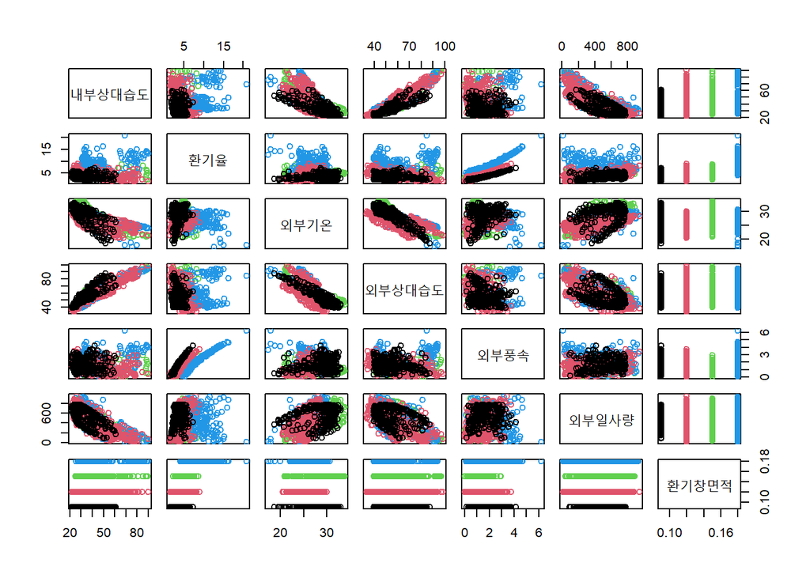

```r
pairs(ex2[1:nrow(plantyes),],col=factor(ex2$환기창면적))
```

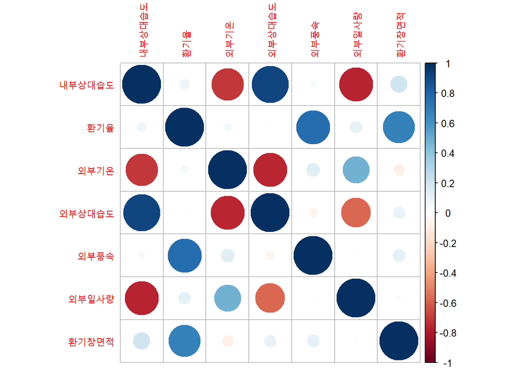

```r
library(corrplot)
corrplot(cor(ex2))
```

- 그리고 각 변수에 대한 기초통계량은 다음과 같이 계산된다.

```r
library(psych)
describe(ex1[,c(-8,-9)])
```

```
##              vars    n   mean     sd median trimmed    mad   min    max  range
## 내부상대습도    1 1055  42.91  15.11  39.40   41.07  13.20 21.50  90.20  68.70
## 환기율          2 1055   5.15   2.58   4.60    4.77   2.08  1.40  20.90  19.50
## 외부기온        3 1055  26.91   2.99  26.90   26.94   3.26 17.30  33.90  16.60
## 외부상대습도    4 1055  59.45  13.87  57.20   58.35  13.94 33.30  98.80  65.50
## 외부풍속        5 1055   1.50   0.92   1.30    1.41   0.83  0.00   6.22   6.21
## 외부일사량      6 1055 459.27 225.19 459.20  460.76 275.02 10.04 950.00 939.96
## 환기창면적      7 1055   0.13   0.03   0.12    0.13   0.04  0.09   0.18   0.09
##               skew kurtosis   se
## 내부상대습도  1.02     0.52 0.47
## 환기율        1.62     3.44 0.08
## 외부기온     -0.12    -0.42 0.09
## 외부상대습도  0.63    -0.26 0.43
## 외부풍속      0.97     0.80 0.03
## 외부일사량   -0.02    -1.02 6.93
## 환기창면적    0.12    -1.38 0.00
```

- 내부상대습도를 반응변수로 하여 각 변수의 주효과와 환기창면적과의 교호작용을 고려한 다중선형회귀모형을 적합하면 다음과 같다.

```r
m_yes <- lm(내부상대습도~환기율+외부기온+외부상대습도+외부풍속+외부일사량+환기창면적+환기창면적*환기율+환기창면적*외부기온+환기창면적*외부상대습도+환기창면적*외부풍속+환기창면적*외부일사량,data=plantyes)
summary(m_yes)
```

```
##
## Call:
## lm(formula = 내부상대습도 ~ 환기율 + 외부기온 + 외부상대습도 +
##     외부풍속 + 외부일사량 + 환기창면적 + 환기창면적 * 환기율 +
##     환기창면적 * 외부기온 + 환기창면적 * 외부상대습도 + 환기창면적 *
##     외부풍속 + 환기창면적 * 외부일사량, data = plantyes)
##
## Residuals:
##      Min       1Q   Median       3Q      Max
## -10.0607  -2.3269   0.0172   2.1738   9.5367
##
## Coefficients:
##                           Estimate Std. Error t value Pr(>|t|)
## (Intercept)               5.062615  11.686975   0.433  0.66497
## 환기율                   -2.008357   0.654492  -3.069  0.00221 **
## 외부기온                  0.134400   0.282375   0.476  0.63420
## 외부상대습도              0.599350   0.064898   9.235  < 2e-16 ***
## 외부풍속                 -4.124660   0.998693  -4.130 3.92e-05 ***
## 외부일사량               -0.032369   0.002421 -13.368  < 2e-16 ***
## 환기창면적               73.225763  83.665230   0.875  0.38165
## 환기율:환기창면적       -15.868184   3.492317  -4.544 6.17e-06 ***
## 외부기온:환기창면적      -1.360807   2.069117  -0.658  0.51089
## 외부상대습도:환기창면적   1.201050   0.449806   2.670  0.00770 **
## 외부풍속:환기창면적      98.082647   7.836997  12.515  < 2e-16 ***
## 외부일사량:환기창면적     0.116906   0.017594   6.644 4.89e-11 ***
## ---
## Signif. codes:  0 '***' 0.001 '**' 0.01 '*' 0.05 '.' 0.1 ' ' 1
##
## Residual standard error: 3.372 on 1043 degrees of freedom
## Multiple R-squared:  0.9507, Adjusted R-squared:  0.9502
## F-statistic:  1830 on 11 and 1043 DF,  p-value: < 2.2e-16
```

- 모형적합 결과 외부기온과 환기창면적이 유의수준 0.05에서 유의미하지 않았다. 그러므로 변수선택 시 외부기온은 제외해야 할 것으로 보인다. 하지만 환기창면적의 경우는 다른 변수들과의 교호작용이 유의미한 경우가 존재하기 때문에 제외할 필요는 없다고 판단된다. 조정된 결정계수의 값이 $R^2_{adj}=0.9502$이므로 작물이 없을 때와 거의 비슷하다.
- 그리고 여러 교호작용들 중 t 통계량의 절대값이 가장 큰 외부풍속과 환기창면적 사이의 교호작용을 가장 중요한 교호작용으로 판단할 수 있다.

#### Best subset selection

- 여러 측도들을 이용하여 모형에 포함될 변수를 적절히 선택해 보도록 하겠다.
- 분석 의뢰기관의 요청에 따라 환기율은 제외하고 분석한다.

```r
library(leaps)
ms0 <- regsubsets(내부상대습도~외부기온+외부상대습도+외부풍속+외부일사량+환기창면적+환기창면적*외부기온+환기창면적*외부상대습도+환기창면적*외부풍속+환기창면적*외부일사량,data=plantyes,nvmax=9)
ms0.summary <- summary(ms0)
ms0.summary
```

```
## Subset selection object
## Call: regsubsets.formula(내부상대습도 ~ 외부기온 + 외부상대습도 + 외부풍속 +
##     외부일사량 + 환기창면적 + 환기창면적 * 외부기온 + 환기창면적 *
##     외부상대습도 + 환기창면적 * 외부풍속 + 환기창면적 * 외부일사량,
##     data = plantyes, nvmax = 9)
## 9 Variables  (and intercept)
##                         Forced in Forced out
## 외부기온                    FALSE      FALSE
## 외부상대습도                FALSE      FALSE
## 외부풍속                    FALSE      FALSE
## 외부일사량                  FALSE      FALSE
## 환기창면적                  FALSE      FALSE
## 외부기온:환기창면적         FALSE      FALSE
## 외부상대습도:환기창면적     FALSE      FALSE
## 외부풍속:환기창면적         FALSE      FALSE
## 외부일사량:환기창면적       FALSE      FALSE
## 1 subsets of each size up to 9
## Selection Algorithm: exhaustive
##          외부기온 외부상대습도 외부풍속 외부일사량 환기창면적
## 1  ( 1 ) " "      "*"          " "      " "        " "
## 2  ( 1 ) " "      "*"          " "      "*"        " "
## 3  ( 1 ) " "      "*"          " "      "*"        " "
## 4  ( 1 ) " "      "*"          " "      "*"        " "
## 5  ( 1 ) " "      "*"          " "      "*"        " "
## 6  ( 1 ) " "      "*"          " "      "*"        "*"
## 7  ( 1 ) "*"      "*"          " "      "*"        "*"
## 8  ( 1 ) "*"      "*"          " "      "*"        "*"
## 9  ( 1 ) "*"      "*"          "*"      "*"        "*"
##          외부기온:환기창면적 외부상대습도:환기창면적 외부풍속:환기창면적
## 1  ( 1 ) " "                 " "                     " "
## 2  ( 1 ) " "                 " "                     " "
## 3  ( 1 ) " "                 "*"                     " "
## 4  ( 1 ) " "                 " "                     "*"
## 5  ( 1 ) " "                 "*"                     "*"
## 6  ( 1 ) " "                 "*"                     "*"
## 7  ( 1 ) " "                 "*"                     "*"
## 8  ( 1 ) "*"                 "*"                     "*"
## 9  ( 1 ) "*"                 "*"                     "*"
##          외부일사량:환기창면적
## 1  ( 1 ) " "
## 2  ( 1 ) " "
## 3  ( 1 ) " "
## 4  ( 1 ) "*"
## 5  ( 1 ) "*"
## 6  ( 1 ) "*"
## 7  ( 1 ) "*"
## 8  ( 1 ) "*"
## 9  ( 1 ) "*"
```

```r
par(mfrow=c(2,2))
# RSS=SSE
plot(ms0.summary$rss,xlab="Number of Variables",ylab="RSS",type="l")
# Adj R^2
plot(ms0.summary$adjr2,xlab="Number of Variables",ylab="Adjusted RSq",type="l")
which.max(ms0.summary$adjr2)
```

```
## [1] 8
```

```r
points(which.max(ms0.summary$adjr2)
,ms0.summary$adjr2[which.max(ms0.summary$adjr2)
], col="red",cex=2,pch=20)
# Cp
plot(ms0.summary$cp,xlab="Number of Variables",ylab="Cp",type='l')
which.min(ms0.summary$cp)
```

```
## [1] 8
```

```r
points(which.min(ms0.summary$cp)
,ms0.summary$cp[which.min(ms0.summary$cp)
],col="red",cex=2,pch=20)
# BIC
plot(ms0.summary$bic,xlab="Number of Variables",ylab="BIC",type='l')
which.min(ms0.summary$bic)
```

```
## [1] 4
```

```r
points(which.min(ms0.summary$bic)
,ms0.summary$bic[which.min(ms0.summary$bic)
],col="red",cex=2,pch=20)
```

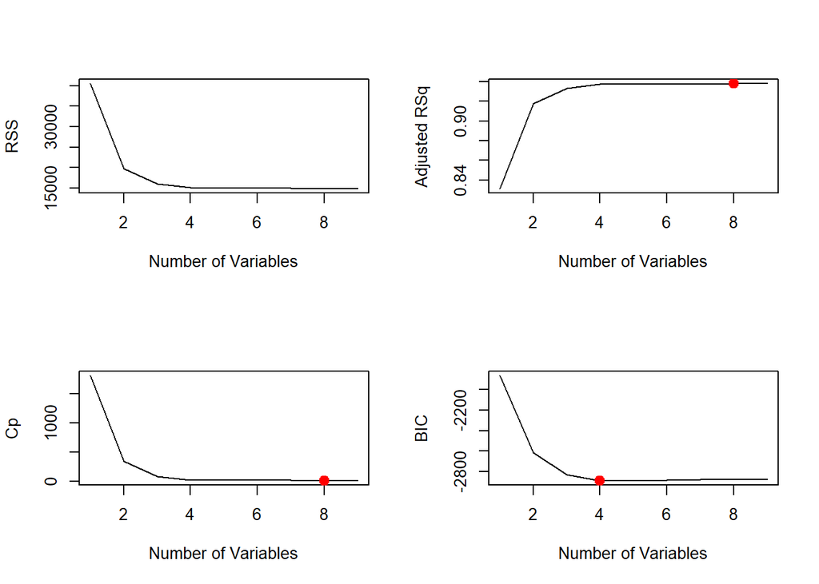

```r
par(mfrow=c(1,1))
```

```r
library(leaps)
ms0 <- regsubsets(내부상대습도~외부상대습도+외부풍속+외부일사량+환기창면적+환기창면적*외부상대습도+환기창면적*외부풍속+환기창면적*외부일사량,data=plantyes,nvmax=7)
ms0.summary <- summary(ms0)
ms0.summary
```

```
## Subset selection object
## Call: regsubsets.formula(내부상대습도 ~ 외부상대습도 + 외부풍속 + 외부일사량 +
##     환기창면적 + 환기창면적 * 외부상대습도 + 환기창면적 * 외부풍속 +
##     환기창면적 * 외부일사량, data = plantyes, nvmax = 7)
## 7 Variables  (and intercept)
##                         Forced in Forced out
## 외부상대습도                FALSE      FALSE
## 외부풍속                    FALSE      FALSE
## 외부일사량                  FALSE      FALSE
## 환기창면적                  FALSE      FALSE
## 외부상대습도:환기창면적     FALSE      FALSE
## 외부풍속:환기창면적         FALSE      FALSE
## 외부일사량:환기창면적       FALSE      FALSE
## 1 subsets of each size up to 7
## Selection Algorithm: exhaustive
##          외부상대습도 외부풍속 외부일사량 환기창면적 외부상대습도:환기창면적
## 1  ( 1 ) "*"          " "      " "        " "        " "
## 2  ( 1 ) "*"          " "      "*"        " "        " "
## 3  ( 1 ) "*"          " "      "*"        " "        "*"
## 4  ( 1 ) "*"          " "      "*"        " "        " "
## 5  ( 1 ) "*"          " "      "*"        " "        "*"
## 6  ( 1 ) "*"          " "      "*"        "*"        "*"
## 7  ( 1 ) "*"          "*"      "*"        "*"        "*"
##          외부풍속:환기창면적 외부일사량:환기창면적
## 1  ( 1 ) " "                 " "
## 2  ( 1 ) " "                 " "
## 3  ( 1 ) " "                 " "
## 4  ( 1 ) "*"                 "*"
## 5  ( 1 ) "*"                 "*"
## 6  ( 1 ) "*"                 "*"
## 7  ( 1 ) "*"                 "*"
```

```r
par(mfrow=c(2,2))
# RSS=SSE
plot(ms0.summary$rss,xlab="Number of Variables",ylab="RSS",type="l")
# Adj R^2
plot(ms0.summary$adjr2,xlab="Number of Variables",ylab="Adjusted RSq",type="l")
which.max(ms0.summary$adjr2)
```

```
## [1] 6
```

```r
points(which.max(ms0.summary$adjr2)
,ms0.summary$adjr2[which.max(ms0.summary$adjr2)
], col="red",cex=2,pch=20)
# Cp
plot(ms0.summary$cp,xlab="Number of Variables",ylab="Cp",type='l')
which.min(ms0.summary$cp)
```

```
## [1] 6
```

```r
points(which.min(ms0.summary$cp)
,ms0.summary$cp[which.min(ms0.summary$cp)
],col="red",cex=2,pch=20)
# BIC
plot(ms0.summary$bic,xlab="Number of Variables",ylab="BIC",type='l')
which.min(ms0.summary$bic)
```

```
## [1] 4
```

```r
points(which.min(ms0.summary$bic)
,ms0.summary$bic[which.min(ms0.summary$bic)
],col="red",cex=2,pch=20)
```

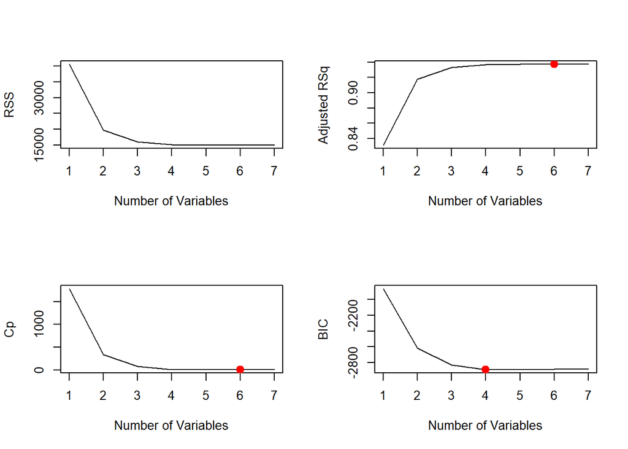

```r
par(mfrow=c(1,1))
```

- 분석결과 $R_{adj}^2$의 경우는 변수의 개수 6인 모형, $Cp$의 경우는 변수의 개수 6인 모형, 그리고 $BIC$의 경우는 변수의 개수 4인 모형을 최적으로 판단하고 있다. 이들 중 가장 단순한 모형인 변수의 개수 4인 모형을 최종적으로 선택하도록 한다. 복잡한 모형이 항상 바람직한 결과를 주지는 않으며 단순한 모형도 설명력이 높은 경우가 많기 때문이다.

#### 교차타당검증에 의한 모형 비교

```r
set.seed(5790)
train.index <- sample(1:nrow(plantyes), round(nrow(plantyes)*7/10), replace=F)
ex1_train <- plantyes[train.index,]
ex1_test <- plantyes[-train.index,]
```

```r
# 모든 주효과, 그리고 환기창면적과 다른 변수들 사이의 교호작용을 포함한 모형
m0 <- lm(내부상대습도~환기율+외부기온+외부상대습도+외부풍속+외부일사량+환기창면적+환기창면적*환기율+환기창면적*외부기온+환기창면적*외부상대습도+환기창면적*외부풍속+환기창면적*외부일사량,data=ex1_train)
y_hat0 <- predict(m0,ex1_test)
RMSE0 <- mean(sum((ex1_test$내부상대습도-y_hat0)^2))
RMSE0
```

```
## [1] 3712.266
```

```r
# Adj R^2, Cp, BIC 등의 기준을 통해 선택된 모형
m0 <- lm(내부상대습도~외부상대습도+외부일사량+환기창면적*외부풍속+환기창면적*외부일사량,data=ex1_train)
y_hat0 <- predict(m0,ex1_test)
RMSE1 <- mean(sum((ex1_test$내부상대습도-y_hat0)^2))
RMSE1
```

```
## [1] 4446.724
```

```r
# 모든 주효과와 가장 중요한 교호작용 1가지를 포함한 모형 (분석 의뢰기관의 요청에 따라 환기율은 제외)
m0 <- lm(내부상대습도~외부기온+외부상대습도+외부풍속+외부일사량+환기창면적+환기창면적*외부풍속,data=ex1_train)
y_hat0 <- predict(m0,ex1_test)
RMSE2 <- mean(sum((ex1_test$내부상대습도-y_hat0)^2))
RMSE2
```

```
## [1] 4425.964
```

- 결과적으로 모든 주효과, 그리고 환기창면적과 다른 변수들 사이의 교호작용을 포함한 모형이 가장 우수하였다.

```r
summary(lm(내부상대습도~환기율+외부기온+외부상대습도+외부풍속+외부일사량+환기창면적+환기창면적*환기율+환기창면적*외부기온+환기창면적*외부상대습도+환기창면적*외부풍속+환기창면적*외부일사량,data=ex1_train))
```

```
##
## Call:
## lm(formula = 내부상대습도 ~ 환기율 + 외부기온 + 외부상대습도 +
##     외부풍속 + 외부일사량 + 환기창면적 + 환기창면적 * 환기율 +
##     환기창면적 * 외부기온 + 환기창면적 * 외부상대습도 + 환기창면적 *
##     외부풍속 + 환기창면적 * 외부일사량, data = ex1_train)
##
## Residuals:
##      Min       1Q   Median       3Q      Max
## -10.3153  -2.3335   0.1059   2.2408   9.7565
##
## Coefficients:
##                          Estimate Std. Error t value Pr(>|t|)
## (Intercept)               3.10482   13.69818   0.227 0.820752
## 환기율                   -2.25066    0.80243  -2.805 0.005169 **
## 외부기온                  0.10139    0.33397   0.304 0.761535
## 외부상대습도              0.64165    0.07570   8.476  < 2e-16 ***
## 외부풍속                 -4.40311    1.19918  -3.672 0.000259 ***
## 외부일사량               -0.03163    0.00295 -10.721  < 2e-16 ***
## 환기창면적               82.57041   97.68641   0.845 0.398244
## 환기율:환기창면적       -16.44268    4.21556  -3.900 0.000105 ***
## 외부기온:환기창면적      -1.13366    2.44331  -0.464 0.642797
## 외부상대습도:환기창면적   1.00170    0.52385   1.912 0.056244 .
## 외부풍속:환기창면적     104.69284    9.19835  11.382  < 2e-16 ***
## 외부일사량:환기창면적     0.12167    0.02137   5.693 1.81e-08 ***
## ---
## Signif. codes:  0 '***' 0.001 '**' 0.01 '*' 0.05 '.' 0.1 ' ' 1
##
## Residual standard error: 3.364 on 726 degrees of freedom
## Multiple R-squared:  0.9525, Adjusted R-squared:  0.9518
## F-statistic:  1324 on 11 and 726 DF,  p-value: < 2.2e-16
```

### 2.3 작물유무 데이터를 합친 경우

#### Multiple Linear Regression Model

- 상관관계에 대한 분석은 작물유무에 따라 데이터를 나누어 분석하는 과정에서 모두 다루었기 때문에 생략하도록 한다.
- 2.1절과 2.2절의 결과를 통해 환기창면적과 환기율, 그리고 환기창면적과 외부풍속 사이의 교호작용이 유의미하다는 사실을 파악할 수 있다.
- 여기에서는 작물유무에 대한 변수가 추가로 들어가고 이에 따라 작물유무에 대한 교호작용을 포함해서 다양한 교호작용 변수를 고려할 수 있지만 모형이 너무 복잡해지므로 바람직하지 않다. 오히려 중요한 교호작용만을 포함한 모형도 충분한 설명력을 가지기 때문이다.
- 따라서 내부상대습도를 반응변수로 하여 각 변수의 주효과와 환기창면적과 환기율, 그리고 환기창면적과 외부풍속 사이의 교호작용을 포함한 모형을 시작점으로 하여 분석을 진행하도록 한다. 여기에 주효과와 작물유무 사이의 교호작용도 우선 포함한다.

```r
m_total <- lm(내부상대습도~환기율+외부기온+외부상대습도+외부풍속+외부일사량+환기창면적+작물유무+환기창면적*환기율+환기창면적*외부풍속+작물유무*환기율+작물유무*외부기온+작물유무*외부상대습도+작물유무*외부풍속+작물유무*외부일사량+작물유무*환기창면적,data=plant)
summary(m_total)
```

```
##
## Call:
## lm(formula = 내부상대습도 ~ 환기율 + 외부기온 + 외부상대습도 +
##     외부풍속 + 외부일사량 + 환기창면적 + 작물유무 + 환기창면적 *
##     환기율 + 환기창면적 * 외부풍속 + 작물유무 * 환기율 + 작물유무 *
##     외부기온 + 작물유무 * 외부상대습도 + 작물유무 * 외부풍속 +
##     작물유무 * 외부일사량 + 작물유무 * 환기창면적, data = plant)
##
## Residuals:
##     Min      1Q  Median      3Q     Max
## -9.5883 -1.5798  0.0229  1.4913  9.7022
##
## Coefficients:
##                            Estimate Std. Error t value Pr(>|t|)
## (Intercept)               1.042e+01  1.914e+00   5.445 5.92e-08 ***
## 환기율                   -5.989e+00  5.699e-01 -10.507  < 2e-16 ***
## 외부기온                 -6.781e-01  5.720e-02 -11.853  < 2e-16 ***
## 외부상대습도              7.650e-01  1.691e-02  45.240  < 2e-16 ***
## 외부풍속                 -1.175e+00  2.608e-01  -4.504 7.09e-06 ***
## 외부일사량               -4.881e-03  7.113e-04  -6.861 9.38e-12 ***
## 환기창면적                9.861e+01  1.090e+01   9.043  < 2e-16 ***
## 작물유무yes              -1.953e+01  2.740e+00  -7.127 1.49e-12 ***
## 환기율:환기창면적        -1.715e+01  1.934e+00  -8.867  < 2e-16 ***
## 외부풍속:환기창면적       8.183e+01  5.125e+00  15.966  < 2e-16 ***
## 환기율:작물유무yes        5.083e+00  6.000e-01   8.471  < 2e-16 ***
## 외부기온:작물유무yes      6.767e-01  7.398e-02   9.146  < 2e-16 ***
## 외부상대습도:작물유무yes  7.674e-04  2.004e-02   0.038 0.969458
## 외부풍속:작물유무yes     -2.407e+00  6.235e-01  -3.861 0.000117 ***
## 외부일사량:작물유무yes   -1.341e-02  8.906e-04 -15.058  < 2e-16 ***
## 환기창면적:작물유무yes    5.803e+01  1.226e+01   4.733 2.39e-06 ***
## ---
## Signif. codes:  0 '***' 0.001 '**' 0.01 '*' 0.05 '.' 0.1 ' ' 1
##
## Residual standard error: 2.914 on 1774 degrees of freedom
## Multiple R-squared:  0.9628, Adjusted R-squared:  0.9625
## F-statistic:  3065 on 15 and 1774 DF,  p-value: < 2.2e-16
```

- 모형적합 결과 외부상대습도와 작물유무 사이의 교호작용이 유의수준 0.05에서 유의미하지 않다. 이는 변수선택 시 제외해야 할 필요가 있다고 보여진다.
- 그리고 가장 중요한 교호작용은 두가지를 선택할 수 있는데 바로 t 통계량의 절대값이 가장 큰 환기창면적과 외부풍속 사이의 교호작용과 t 통계량의 절대값이 두번째로 큰 외부일사량과 작물유무 사이의 교호작용이라고 판단된다.
- 조정된 결정계수의 값이 $R^2_{adj}=0.9625$이다.

#### Best subset selection

- 여러 측도들을 이용하여 모형에 포함될 변수를 적절히 선택해 보도록 하겠다.
- 분석 의뢰기관의 요청에 따라 환기율은 분석에서 제외한다.

```r
library(leaps)
ms0 <- regsubsets(내부상대습도~외부기온+외부상대습도+외부풍속+외부일사량+환기창면적+작물유무+환기창면적*외부풍속+작물유무*외부기온+작물유무*외부상대습도+작물유무*외부풍속+작물유무*외부일사량+작물유무*환기창면적,data=plant,nvmax=12)
ms0.summary <- summary(ms0)
ms0.summary
```

```
## Subset selection object
## Call: regsubsets.formula(내부상대습도 ~ 외부기온 + 외부상대습도 + 외부풍속 +
##     외부일사량 + 환기창면적 + 작물유무 + 환기창면적 * 외부풍속 +
##     작물유무 * 외부기온 + 작물유무 * 외부상대습도 + 작물유무 *
##     외부풍속 + 작물유무 * 외부일사량 + 작물유무 * 환기창면적,
##     data = plant, nvmax = 12)
## 12 Variables  (and intercept)
##                          Forced in Forced out
## 외부기온                     FALSE      FALSE
## 외부상대습도                 FALSE      FALSE
## 외부풍속                     FALSE      FALSE
## 외부일사량                   FALSE      FALSE
## 환기창면적                   FALSE      FALSE
## 작물유무yes                  FALSE      FALSE
## 외부풍속:환기창면적          FALSE      FALSE
## 외부기온:작물유무yes         FALSE      FALSE
## 외부상대습도:작물유무yes     FALSE      FALSE
## 외부풍속:작물유무yes         FALSE      FALSE
## 외부일사량:작물유무yes       FALSE      FALSE
## 환기창면적:작물유무yes       FALSE      FALSE
## 1 subsets of each size up to 12
## Selection Algorithm: exhaustive
##           외부기온 외부상대습도 외부풍속 외부일사량 환기창면적 작물유무yes
## 1  ( 1 )  " "      "*"          " "      " "        " "        " "
## 2  ( 1 )  " "      "*"          " "      "*"        " "        " "
## 3  ( 1 )  " "      "*"          " "      "*"        " "        " "
## 4  ( 1 )  " "      "*"          " "      "*"        "*"        " "
## 5  ( 1 )  " "      "*"          " "      "*"        "*"        " "
## 6  ( 1 )  "*"      "*"          " "      "*"        "*"        " "
## 7  ( 1 )  "*"      "*"          " "      "*"        "*"        " "
## 8  ( 1 )  "*"      "*"          " "      "*"        "*"        "*"
## 9  ( 1 )  "*"      "*"          " "      "*"        "*"        "*"
## 10  ( 1 ) "*"      "*"          "*"      "*"        "*"        "*"
## 11  ( 1 ) "*"      "*"          "*"      "*"        "*"        "*"
## 12  ( 1 ) "*"      "*"          "*"      "*"        "*"        "*"
##           외부풍속:환기창면적 외부기온:작물유무yes 외부상대습도:작물유무yes
## 1  ( 1 )  " "                 " "                  " "
## 2  ( 1 )  " "                 " "                  " "
## 3  ( 1 )  "*"                 " "                  " "
## 4  ( 1 )  " "                 " "                  " "
## 5  ( 1 )  " "                 " "                  " "
## 6  ( 1 )  " "                 "*"                  " "
## 7  ( 1 )  "*"                 "*"                  " "
## 8  ( 1 )  "*"                 "*"                  " "
## 9  ( 1 )  "*"                 "*"                  " "
## 10  ( 1 ) "*"                 "*"                  " "
## 11  ( 1 ) "*"                 "*"                  " "
## 12  ( 1 ) "*"                 "*"                  "*"
##           외부풍속:작물유무yes 외부일사량:작물유무yes 환기창면적:작물유무yes
## 1  ( 1 )  " "                  " "                    " "
## 2  ( 1 )  " "                  " "                    " "
## 3  ( 1 )  " "                  " "                    " "
## 4  ( 1 )  " "                  "*"                    " "
## 5  ( 1 )  "*"                  "*"                    " "
## 6  ( 1 )  " "                  "*"                    " "
## 7  ( 1 )  " "                  "*"                    " "
## 8  ( 1 )  " "                  "*"                    " "
## 9  ( 1 )  " "                  "*"                    "*"
## 10  ( 1 ) " "                  "*"                    "*"
## 11  ( 1 ) "*"                  "*"                    "*"
## 12  ( 1 ) "*"                  "*"                    "*"
```

```r
par(mfrow=c(2,2))
# RSS=SSE
plot(ms0.summary$rss,xlab="Number of Variables",ylab="RSS",type="l")
# Adj R^2
plot(ms0.summary$adjr2,xlab="Number of Variables",ylab="Adjusted RSq",type="l")
which.max(ms0.summary$adjr2)
```

```
## [1] 11
```

```r
points(which.max(ms0.summary$adjr2)
,ms0.summary$adjr2[which.max(ms0.summary$adjr2)
], col="red",cex=2,pch=20)
# Cp
plot(ms0.summary$cp,xlab="Number of Variables",ylab="Cp",type='l')
which.min(ms0.summary$cp)
```

```
## [1] 11
```

```r
points(which.min(ms0.summary$cp)
,ms0.summary$cp[which.min(ms0.summary$cp)
],col="red",cex=2,pch=20)
# BIC
plot(ms0.summary$bic,xlab="Number of Variables",ylab="BIC",type='l')
which.min(ms0.summary$bic)
```

```
## [1] 9
```

```r
points(which.min(ms0.summary$bic)
,ms0.summary$bic[which.min(ms0.summary$bic)
],col="red",cex=2,pch=20)
```

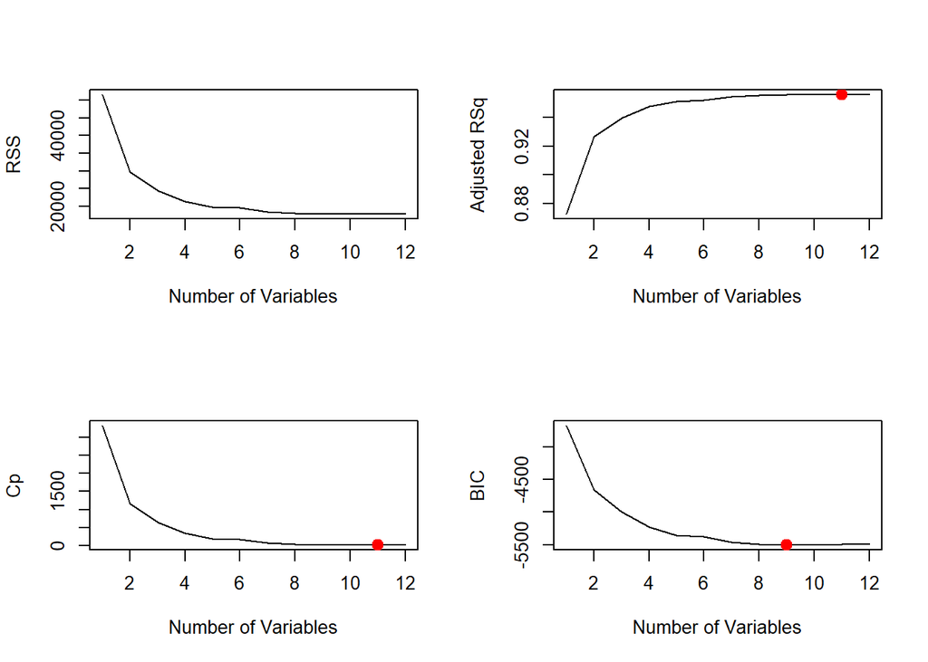

```r
par(mfrow=c(1,1))
```

- 외부풍속을 제외하는 것이 좋다는 결과이다.
- 외부풍속을 제외한 모형에 대해서 다시한번 선택해 보자.

```r
library(leaps)
ms0 <- regsubsets(내부상대습도~외부기온+외부상대습도+외부일사량+환기창면적+작물유무+작물유무*외부기온+작물유무*외부상대습도+작물유무*외부일사량+작물유무*환기창면적,data=plant,nvmax=9)
ms0.summary <- summary(ms0)
ms0.summary
```

```
## Subset selection object
## Call: regsubsets.formula(내부상대습도 ~ 외부기온 + 외부상대습도 + 외부일사량 +
##     환기창면적 + 작물유무 + 작물유무 * 외부기온 + 작물유무 *
##     외부상대습도 + 작물유무 * 외부일사량 + 작물유무 * 환기창면적,
##     data = plant, nvmax = 9)
## 9 Variables  (and intercept)
##                          Forced in Forced out
## 외부기온                     FALSE      FALSE
## 외부상대습도                 FALSE      FALSE
## 외부일사량                   FALSE      FALSE
## 환기창면적                   FALSE      FALSE
## 작물유무yes                  FALSE      FALSE
## 외부기온:작물유무yes         FALSE      FALSE
## 외부상대습도:작물유무yes     FALSE      FALSE
## 외부일사량:작물유무yes       FALSE      FALSE
## 환기창면적:작물유무yes       FALSE      FALSE
## 1 subsets of each size up to 9
## Selection Algorithm: exhaustive
##          외부기온 외부상대습도 외부일사량 환기창면적 작물유무yes
## 1  ( 1 ) " "      "*"          " "        " "        " "
## 2  ( 1 ) " "      "*"          "*"        " "        " "
## 3  ( 1 ) " "      "*"          "*"        "*"        " "
## 4  ( 1 ) " "      "*"          "*"        "*"        " "
## 5  ( 1 ) " "      "*"          "*"        "*"        " "
## 6  ( 1 ) "*"      "*"          "*"        "*"        " "
## 7  ( 1 ) "*"      "*"          "*"        "*"        "*"
## 8  ( 1 ) "*"      "*"          "*"        "*"        "*"
## 9  ( 1 ) "*"      "*"          "*"        "*"        "*"
##          외부기온:작물유무yes 외부상대습도:작물유무yes 외부일사량:작물유무yes
## 1  ( 1 ) " "                  " "                      " "
## 2  ( 1 ) " "                  " "                      " "
## 3  ( 1 ) " "                  " "                      " "
## 4  ( 1 ) " "                  " "                      "*"
## 5  ( 1 ) "*"                  " "                      "*"
## 6  ( 1 ) "*"                  " "                      "*"
## 7  ( 1 ) "*"                  " "                      "*"
## 8  ( 1 ) "*"                  " "                      "*"
## 9  ( 1 ) "*"                  "*"                      "*"
##          환기창면적:작물유무yes
## 1  ( 1 ) " "
## 2  ( 1 ) " "
## 3  ( 1 ) " "
## 4  ( 1 ) " "
## 5  ( 1 ) " "
## 6  ( 1 ) " "
## 7  ( 1 ) " "
## 8  ( 1 ) "*"
## 9  ( 1 ) "*"
```

```r
par(mfrow=c(2,2))
# RSS=SSE
plot(ms0.summary$rss,xlab="Number of Variables",ylab="RSS",type="l")
# Adj R^2
plot(ms0.summary$adjr2,xlab="Number of Variables",ylab="Adjusted RSq",type="l")
which.max(ms0.summary$adjr2)
```

```
## [1] 8
```

```r
points(which.max(ms0.summary$adjr2)
,ms0.summary$adjr2[which.max(ms0.summary$adjr2)
], col="red",cex=2,pch=20)
# Cp
plot(ms0.summary$cp,xlab="Number of Variables",ylab="Cp",type='l')
which.min(ms0.summary$cp)
```

```
## [1] 8
```

```r
points(which.min(ms0.summary$cp)
,ms0.summary$cp[which.min(ms0.summary$cp)
],col="red",cex=2,pch=20)
# BIC
plot(ms0.summary$bic,xlab="Number of Variables",ylab="BIC",type='l')
which.min(ms0.summary$bic)
```

```
## [1] 8
```

```r
points(which.min(ms0.summary$bic)
,ms0.summary$bic[which.min(ms0.summary$bic)
],col="red",cex=2,pch=20)
```

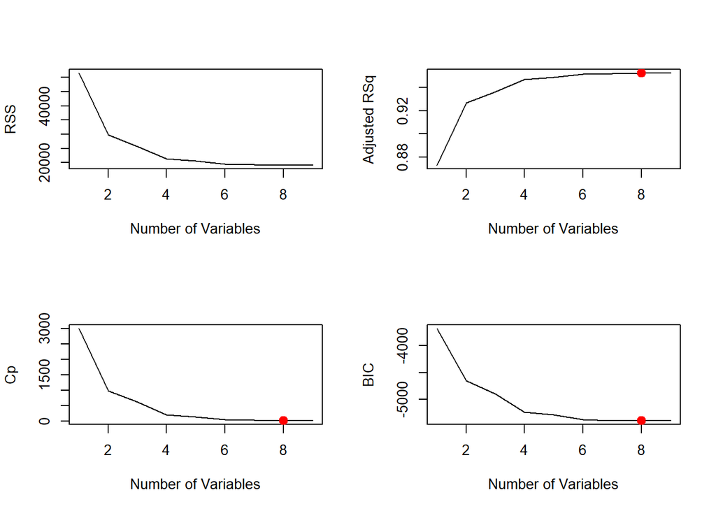

```r
par(mfrow=c(1,1))
```

- 분석결과 $R_{adj}^2$의 경우는 변수의 개수 8인 모형, $Cp$의 경우는 변수의 개수 8인 모형, 그리고 $BIC$의 경우는 변수의 개수 8인 모형을 최적으로 판단하고 있다. 이에 따라 변수의 개수 8인 모형을 최종적으로 선택하도록 한다.

```r
summary(lm(내부상대습도~외부기온+외부상대습도+외부일사량+환기창면적+작물유무+작물유무*외부기온+작물유무*외부일사량+작물유무*환기창면적,data=plant))
```

```
##
## Call:
## lm(formula = 내부상대습도 ~ 외부기온 + 외부상대습도 + 외부일사량 +
##     환기창면적 + 작물유무 + 작물유무 * 외부기온 + 작물유무 *
##     외부일사량 + 작물유무 * 환기창면적, data = plant)
##
## Residuals:
##      Min       1Q   Median       3Q      Max
## -11.8864  -1.7298  -0.0203   1.7562  11.5932
##
## Coefficients:
##                          Estimate Std. Error t value Pr(>|t|)
## (Intercept)             1.262e+01  1.506e+00   8.379  < 2e-16 ***
## 외부기온               -6.473e-01  5.824e-02 -11.114  < 2e-16 ***
## 외부상대습도            7.486e-01  1.005e-02  74.486  < 2e-16 ***
## 외부일사량             -7.926e-03  7.495e-04 -10.574  < 2e-16 ***
## 환기창면적              4.070e+01  2.689e+00  15.137  < 2e-16 ***
## 작물유무yes            -1.055e+01  1.764e+00  -5.981 2.68e-09 ***
## 외부기온:작물유무yes    6.585e-01  6.882e-02   9.568  < 2e-16 ***
## 외부일사량:작물유무yes -1.680e-02  9.127e-04 -18.401  < 2e-16 ***
## 환기창면적:작물유무yes  1.417e+01  4.028e+00   3.518 0.000445 ***
## ---
## Signif. codes:  0 '***' 0.001 '**' 0.01 '*' 0.05 '.' 0.1 ' ' 1
##
## Residual standard error: 3.278 on 1781 degrees of freedom
## Multiple R-squared:  0.9528, Adjusted R-squared:  0.9526
## F-statistic:  4494 on 8 and 1781 DF,  p-value: < 2.2e-16
```

#### 교차타당검증에 의한 모형 비교

```r
set.seed(5790)
train.index <- sample(1:nrow(plant), round(nrow(plant)*7/10), replace=F)
ex1_train <- plant[train.index,]
ex1_test <- plant[-train.index,]
```

```r
# 최초로 고려한 모형
m0 <- lm(내부상대습도~환기율+외부기온+외부상대습도+외부풍속+외부일사량+환기창면적+작물유무+환기창면적*환기율+환기창면적*외부풍속+작물유무*환기율+작물유무*외부기온+작물유무*외부상대습도+작물유무*외부풍속+작물유무*외부일사량+작물유무*환기창면적,data=ex1_train)
y_hat0 <- predict(m0,ex1_test)
RMSE0 <- mean(sum((ex1_test$내부상대습도-y_hat0)^2))
RMSE0
```

```
## [1] 4366.145
```

```r
# Adj R^2, Cp, BIC 등의 기준을 바탕으로 선택된 모형 (교호작용이 있는 경우는 주효과 포함)
m0 <- lm(내부상대습도~외부기온+외부상대습도+외부일사량+환기창면적+작물유무+작물유무*외부기온+작물유무*외부일사량+작물유무*환기창면적,data=plant)
y_hat0 <- predict(m0,ex1_test)
RMSE1 <- mean(sum((ex1_test$내부상대습도-y_hat0)^2))
RMSE1
```

```
## [1] 5466.197
```

```r
# 모든 주효과와 가장 중요한 교호작용 2가지를 포함한 모형
# 분석 의뢰기관의 요청에 따라 환기율은 제외
m0 <- lm(내부상대습도~외부기온+외부상대습도+외부풍속+외부일사량+환기창면적+작물유무+환기창면적*외부풍속+작물유무*외부일사량,data=ex1_train)
y_hat0 <- predict(m0,ex1_test)
RMSE2 <- mean(sum((ex1_test$내부상대습도-y_hat0)^2))
RMSE2
```

```
## [1] 5477.551
```

- 결과적으로 3가지 모형들 중 최초로 고려한 모형이 가장 우수하였다.

```r
summary(lm(내부상대습도~환기율+외부기온+외부상대습도+외부풍속+외부일사량+환기창면적+작물유무+환기창면적*환기율+환기창면적*외부풍속+작물유무*환기율+작물유무*외부기온+작물유무*외부상대습도+작물유무*외부풍속+작물유무*외부일사량+작물유무*환기창면적,data=ex1_train))
```

```
##
## Call:
## lm(formula = 내부상대습도 ~ 환기율 + 외부기온 + 외부상대습도 +
##     외부풍속 + 외부일사량 + 환기창면적 + 작물유무 + 환기창면적 *
##     환기율 + 환기창면적 * 외부풍속 + 작물유무 * 환기율 + 작물유무 *
##     외부기온 + 작물유무 * 외부상대습도 + 작물유무 * 외부풍속 +
##     작물유무 * 외부일사량 + 작물유무 * 환기창면적, data = ex1_train)
##
## Residuals:
##     Min      1Q  Median      3Q     Max
## -9.9186 -1.6237  0.0084  1.5017  9.4928
##
## Coefficients:
##                            Estimate Std. Error t value Pr(>|t|)
## (Intercept)               9.818e+00  2.298e+00   4.272 2.09e-05 ***
## 환기율                   -6.100e+00  6.930e-01  -8.802  < 2e-16 ***
## 외부기온                 -6.928e-01  6.726e-02 -10.299  < 2e-16 ***
## 외부상대습도              7.802e-01  2.049e-02  38.083  < 2e-16 ***
## 외부풍속                 -1.153e+00  3.109e-01  -3.707 0.000219 ***
## 외부일사량               -4.236e-03  8.638e-04  -4.904 1.07e-06 ***
## 환기창면적                9.873e+01  1.337e+01   7.386 2.78e-13 ***
## 작물유무yes              -1.915e+01  3.269e+00  -5.857 6.03e-09 ***
## 환기율:환기창면적        -1.763e+01  2.357e+00  -7.479 1.42e-13 ***
## 외부풍속:환기창면적       8.333e+01  6.260e+00  13.311  < 2e-16 ***
## 환기율:작물유무yes        5.289e+00  7.360e-01   7.186 1.15e-12 ***
## 외부기온:작물유무yes      6.986e-01  8.742e-02   7.991 3.04e-15 ***
## 외부상대습도:작물유무yes -5.611e-03  2.413e-02  -0.233 0.816178
## 외부풍속:작물유무yes     -2.654e+00  7.562e-01  -3.510 0.000465 ***
## 외부일사량:작물유무yes   -1.411e-02  1.073e-03 -13.157  < 2e-16 ***
## 환기창면적:작물유무yes    5.420e+01  1.473e+01   3.679 0.000244 ***
## ---
## Signif. codes:  0 '***' 0.001 '**' 0.01 '*' 0.05 '.' 0.1 ' ' 1
##
## Residual standard error: 2.947 on 1237 degrees of freedom
## Multiple R-squared:  0.9634, Adjusted R-squared:  0.963
## F-statistic:  2172 on 15 and 1237 DF,  p-value: < 2.2e-16
```